# Regression analysis

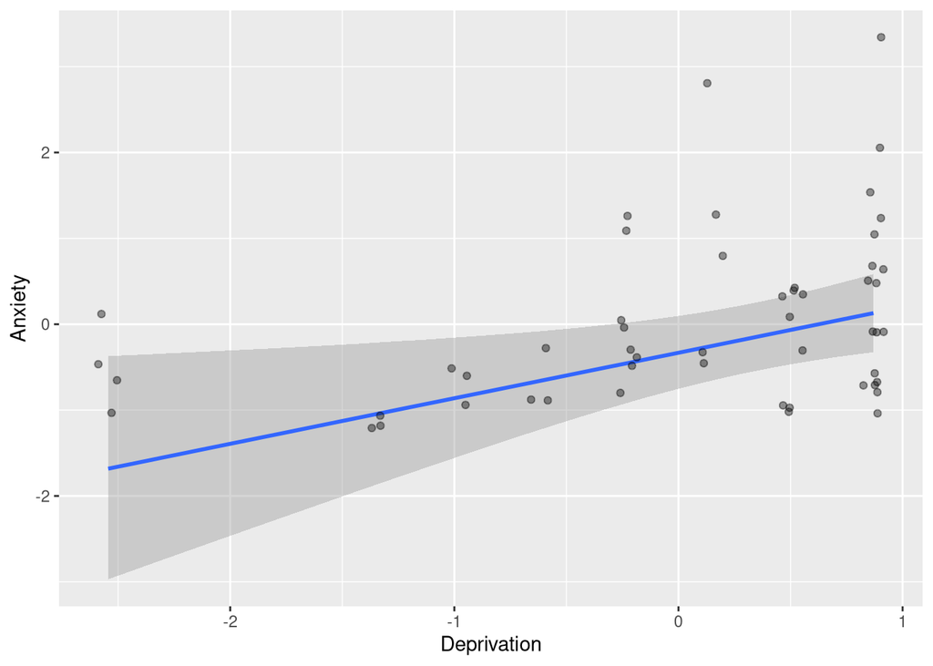

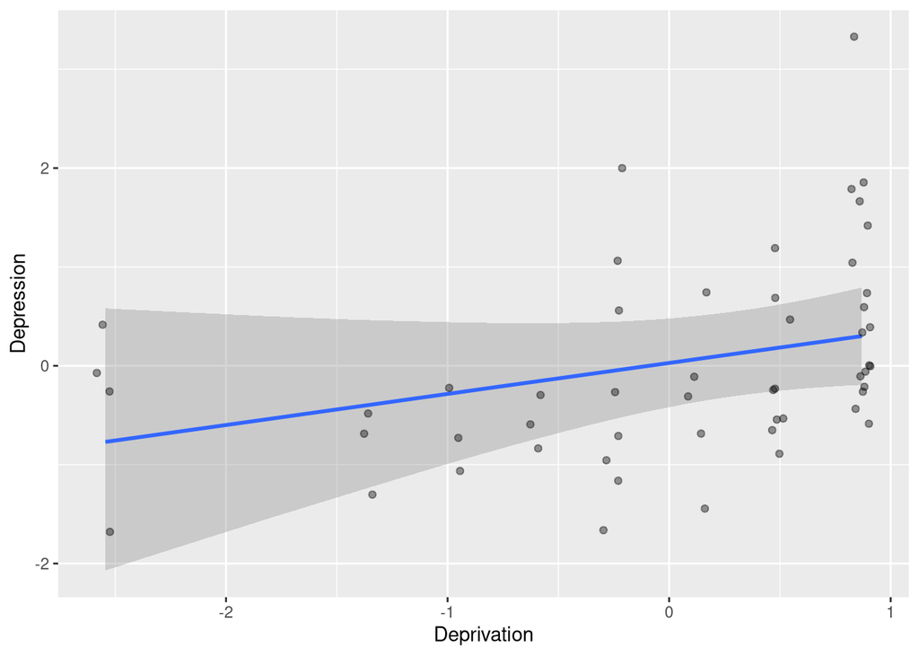

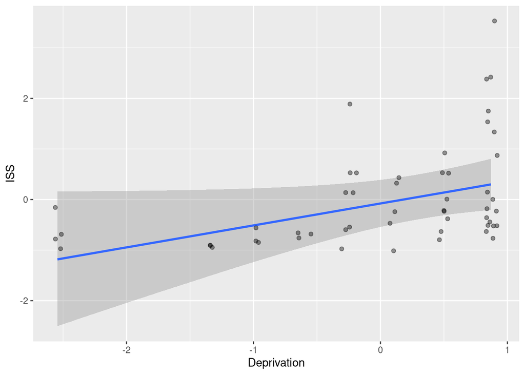

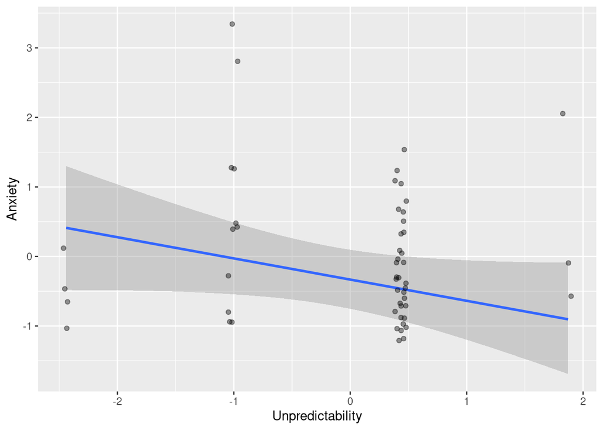

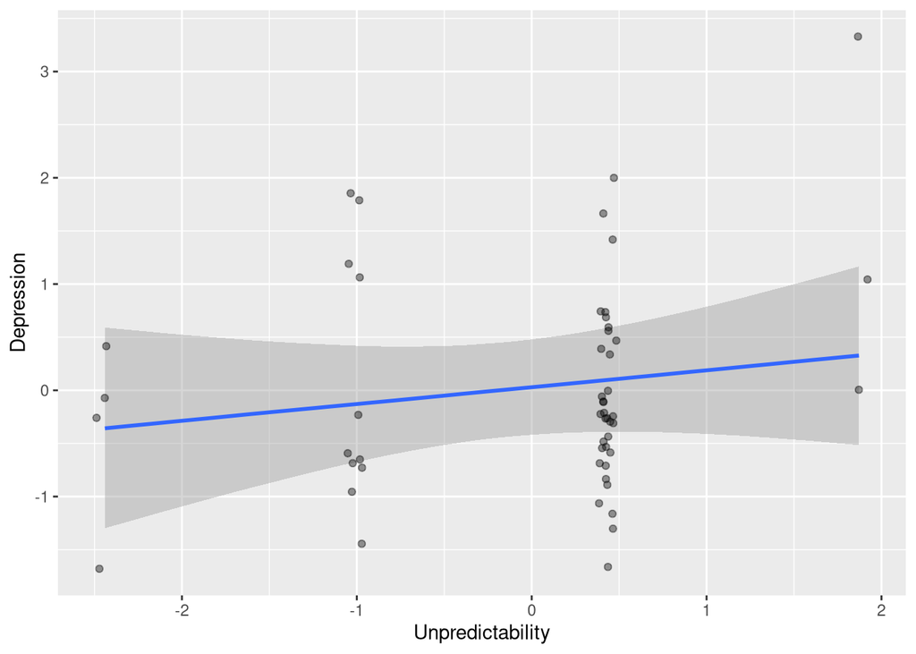

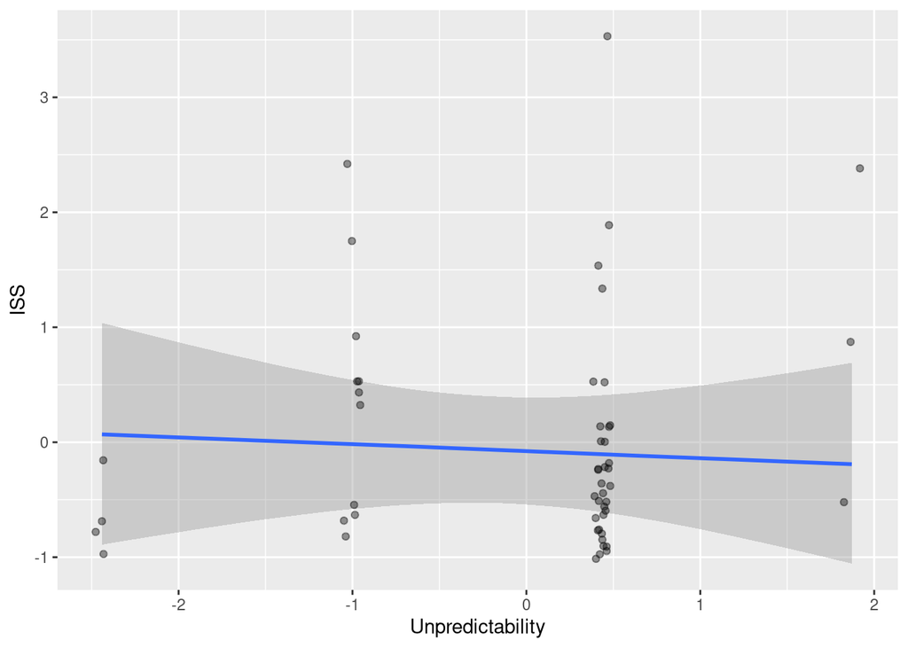

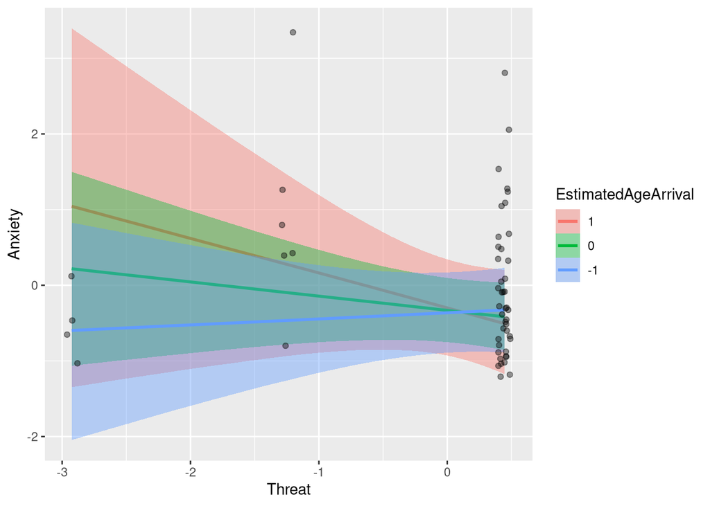

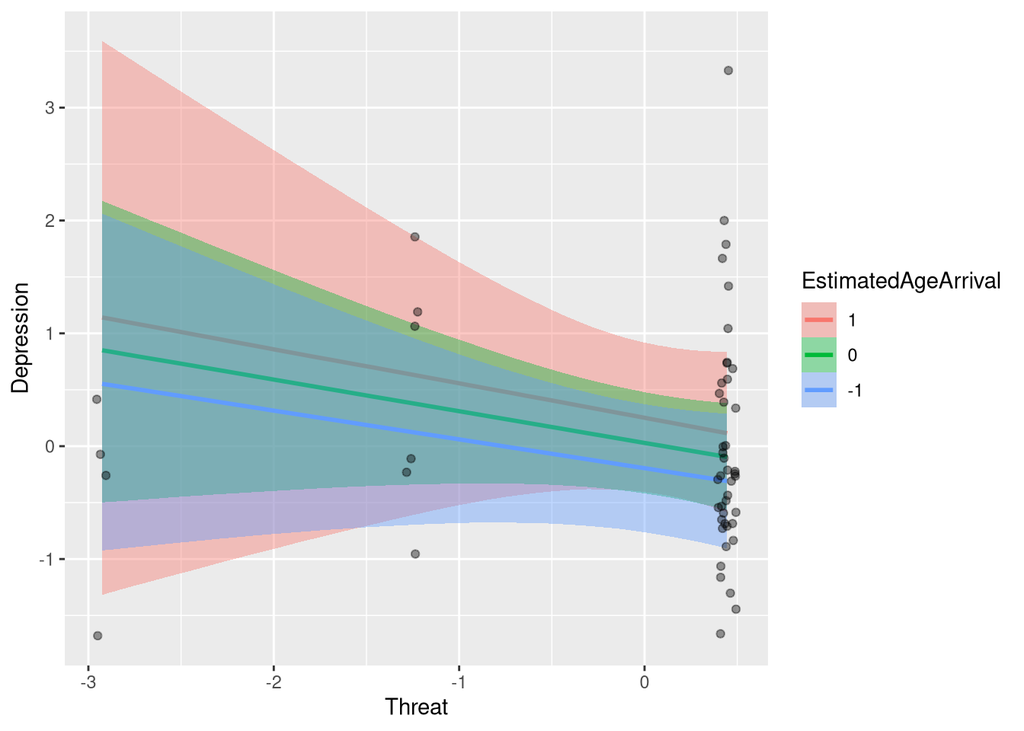

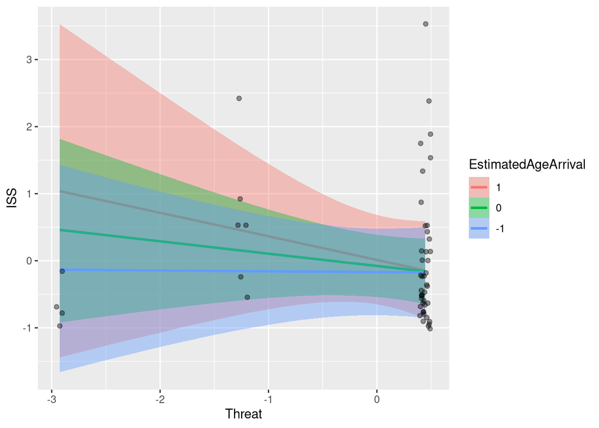

[7 more figures not shown]

#### Prior and posterior predictive checks

##### Density overlays

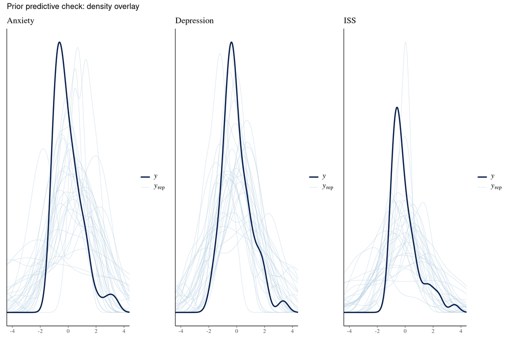

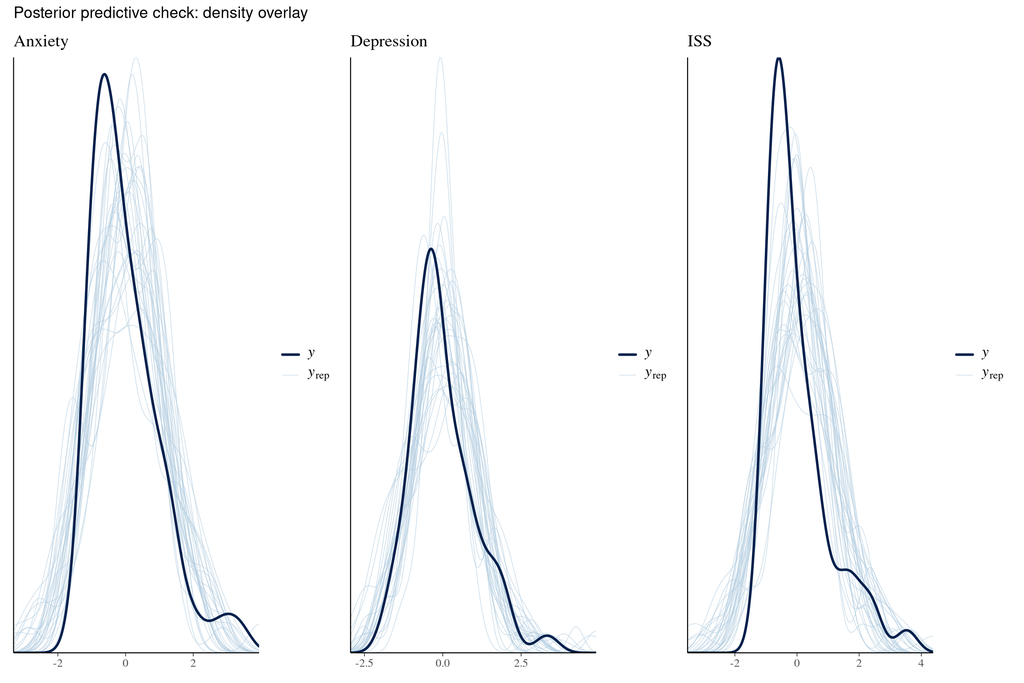

##### Minimum, Maximum and Skewness

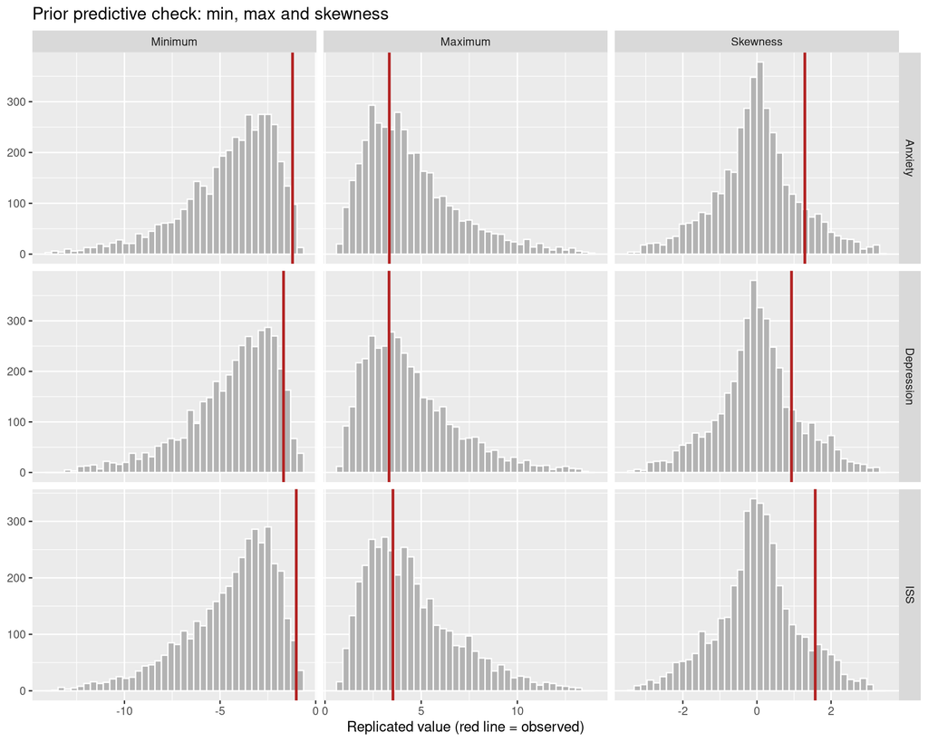

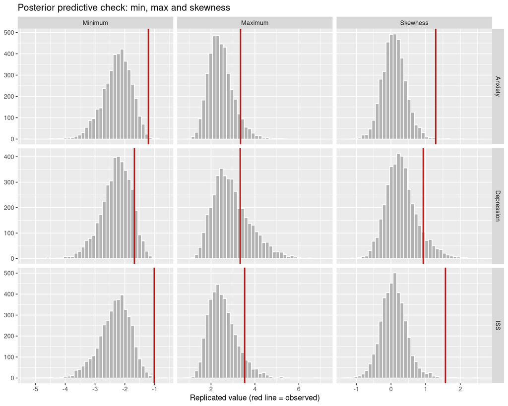

##### Pairwise correlation between dependent variables

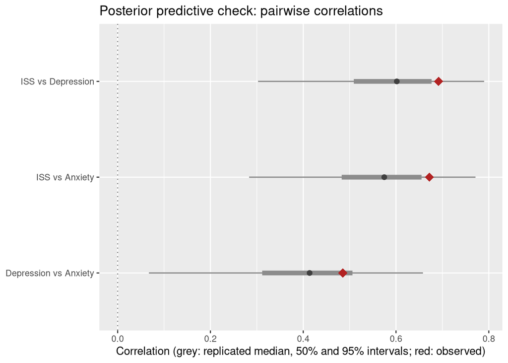

### Model 2B - Moderation effect of the estimated age at arrival to the centre for the cumulative risk approach

| Parameter | Posterior Estimate | Posterior **95% CrI** | P(direction) | Convergence Rhat | Convergence Bulk ESS | Convergence Tail ESS |
| --- | --- | --- | --- | --- | --- | --- |
| Model 2B |  |  |  |  |  |  |
| Anxiety_Sex_2female | −0.26 | [−0.72, 0.21] | 0.872 | 1.001 | 4,990 | 5,300 |
| Anxiety_Sex_2male | 0.22 | [−0.22, 0.66] | 0.847 | 1.001 | 4,334 | 4,375 |
| Anxiety_CRS_2 | −0.02 | [−0.39, 0.35] | 0.542 | 1.001 | 3,714 | 4,975 |
| Anxiety_EstimatedAgeArrival | 0.33 | [−0.06, 0.71] | 0.951 | 1.001 | 3,976 | 4,995 |
| Anxiety_CRS_2:EstimatedAgeArrival | −0.07 | [−0.41, 0.27] | 0.665 | 1.001 | 3,512 | 4,284 |
| Depression_Sex_2female | 0.05 | [−0.38, 0.47] | 0.586 | 1.001 | 5,111 | 5,069 |
| Depression_Sex_2male | −0.10 | [−0.48, 0.31] | 0.698 | 1.001 | 4,375 | 4,165 |
| Depression_CRS_2 | 0.11 | [−0.24, 0.46] | 0.732 | 1.002 | 3,745 | 4,763 |
| Depression_EstimatedAgeArrival | 0.33 | [−0.03, 0.69] | 0.964 | 1.002 | 3,746 | 5,128 |
| Depression_CRS_2:EstimatedAgeArrival | 0.13 | [−0.18, 0.46] | 0.795 | 1.002 | 3,414 | 5,170 |
| ISS_Sex_2female | −0.03 | [−0.46, 0.41] | 0.551 | 1.002 | 4,980 | 4,940 |
| ISS_Sex_2male | 0.06 | [−0.35, 0.46] | 0.610 | 1.002 | 4,658 | 4,607 |
| ISS_CRS_2 | 0.10 | [−0.27, 0.48] | 0.706 | 1.002 | 3,383 | 4,893 |
| ISS_EstimatedAgeArrival | 0.27 | [−0.14, 0.70] | 0.899 | 1.002 | 3,420 | 4,481 |
| ISS_CRS_2:EstimatedAgeArrival | −0.02 | [−0.35, 0.32] | 0.548 | 1.002 | 3,404 | 4,555 |
| sd_Species_2__Anxiety_Intercept | 0.31 | [0.02, 0.97] |  | 1.004 | 2,323 | 2,004 |
| sd_Species_2__Depression_Intercept | 0.19 | [0.01, 0.76] |  | 1.003 | 2,917 | 3,115 |
| sd_Species_2__ISS_Intercept | 0.21 | [0.01, 0.78] |  | 1.002 | 2,512 | 2,376 |
| sigma_Anxiety | 0.92 | [0.76, 1.14] |  | 1.002 | 5,901 | 5,359 |
| sigma_Depression | 0.87 | [0.72, 1.08] |  | 1.001 | 5,927 | 5,429 |
| sigma_ISS | 0.93 | [0.76, 1.15] |  | 1.001 | 5,518 | 4,734 |
| rescor__Anxiety__Depression | 0.46 | [0.21, 0.65] | 1.000 | 1.001 | 5,339 | 5,622 |
| rescor__Anxiety__ISS | 0.60 | [0.38, 0.75] | 1.000 | 1.001 | 5,561 | 5,523 |
| rescor__Depression__ISS | 0.60 | [0.38, 0.76] | 1.000 | 1.002 | 6,188 | 5,424 |

Estimates are posterior medians or means pooled across imputed datasets; intervals are equal-tailed 95% CrIs.  
P(direction) = probability of direction.  
Convergence diagnostics are the worst values across imputations; shaded cells have Rhat > 1.01 or ESS < 400.

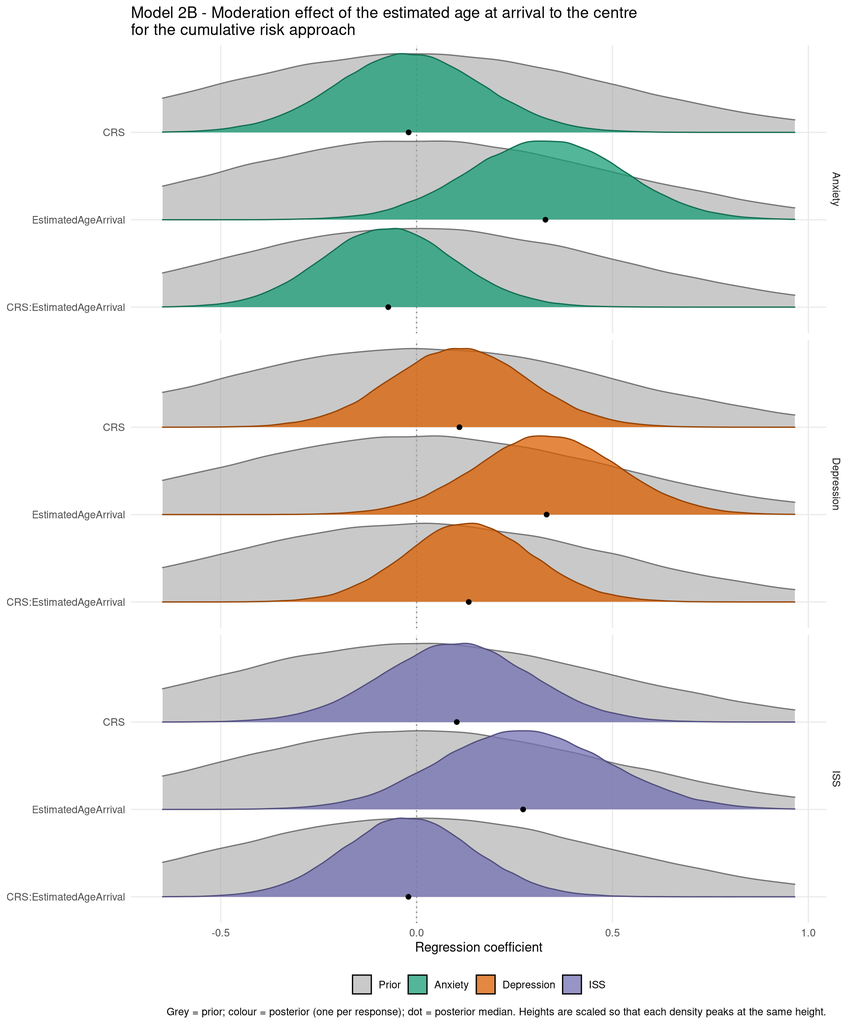

#### Prior and posterior predictive checks

##### Density overlays

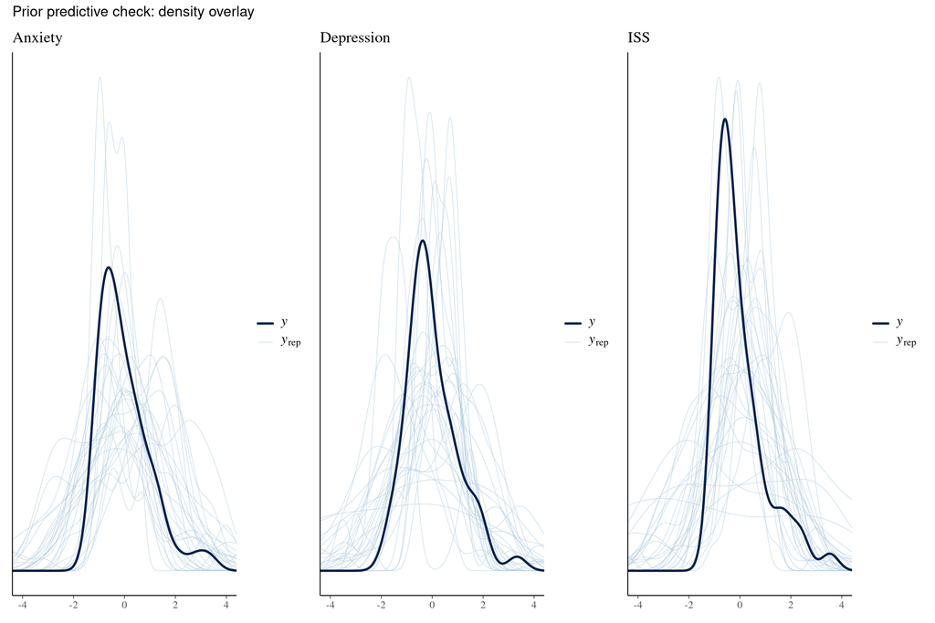

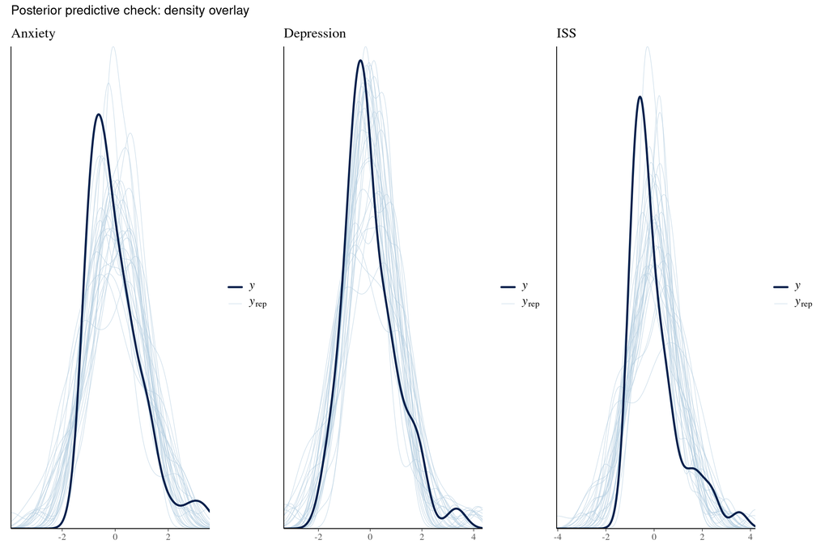

##### Minimum, Maximum and Skewness

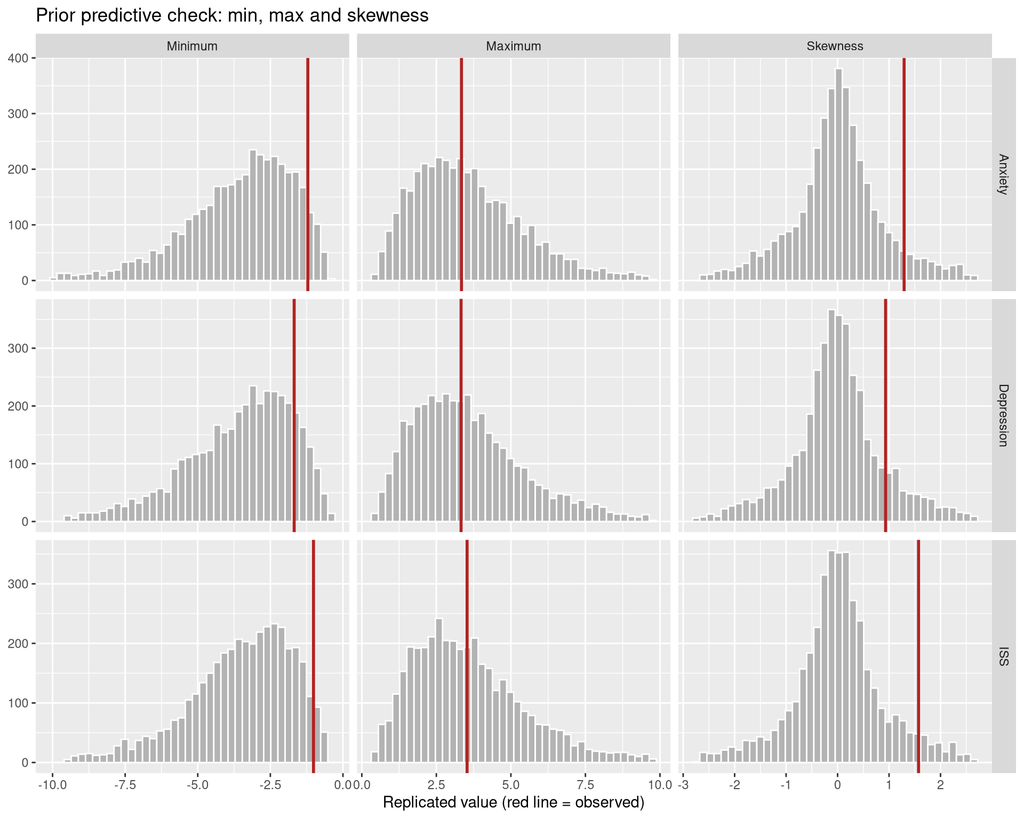

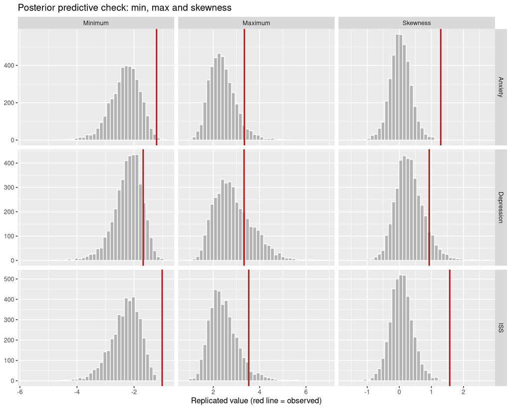

##### Pairwise correlation between dependent variables

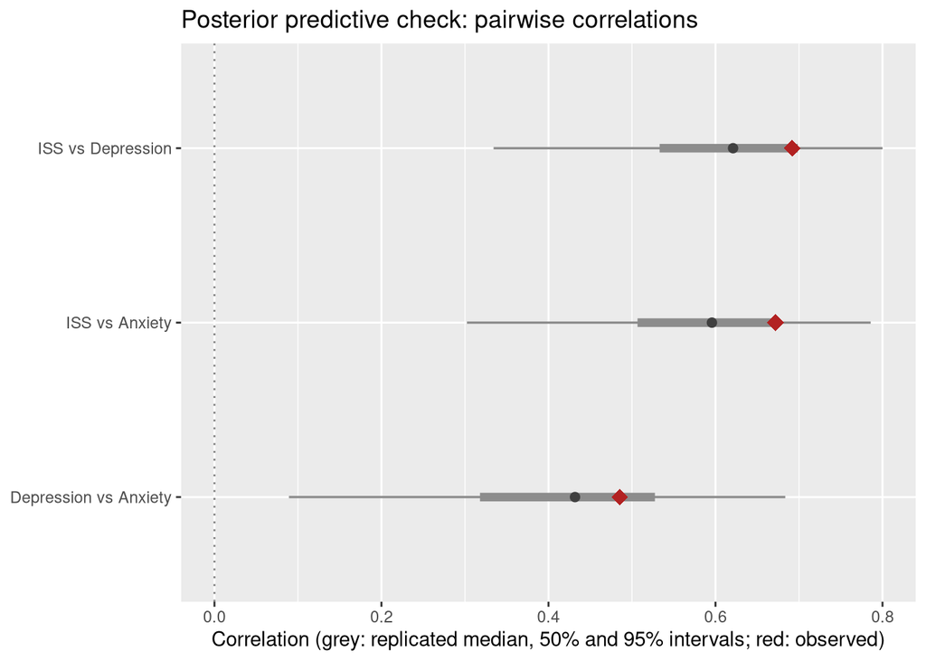

### Model 3A - Moderation effect of the number of years spent at the centre for the dimensional approach

| Parameter | Posterior Estimate | Posterior **95% CrI** | P(direction) | Convergence Rhat | Convergence Bulk ESS | Convergence Tail ESS |
| --- | --- | --- | --- | --- | --- | --- |
| Model 3A |  |  |  |  |  |  |
| Anxiety_Sex_2female | −0.31 | [−0.73, 0.12] | 0.925 | 1.001 | 5,142 | 4,551 |
| Anxiety_Sex_2male | 0.19 | [−0.23, 0.61] | 0.827 | 1.001 | 4,697 | 5,008 |
| Anxiety_Threat | −0.16 | [−0.54, 0.23] | 0.791 | 1.002 | 5,220 | 5,312 |
| Anxiety_YearsCenter | −0.06 | [−0.36, 0.26] | 0.643 | 1.002 | 4,885 | 5,192 |
| Anxiety_Deprivation | 0.62 | [0.29, 0.91] | 1.000 | 1.001 | 5,158 | 4,840 |
| Anxiety_Unpredictability | −0.27 | [−0.65, 0.12] | 0.914 | 1.001 | 4,697 | 4,953 |
| Anxiety_Threat:YearsCenter | 0.20 | [−0.30, 0.83] | 0.758 | 1.002 | 4,675 | 4,958 |
| Anxiety_YearsCenter:Deprivation | −0.03 | [−0.38, 0.31] | 0.574 | 1.001 | 5,216 | 5,131 |
| Anxiety_YearsCenter:Unpredictability | −0.20 | [−1.01, 0.36] | 0.721 | 1.002 | 4,598 | 4,899 |
| Depression_Sex_2female | 0.12 | [−0.31, 0.54] | 0.712 | 1.001 | 5,358 | 5,175 |
| Depression_Sex_2male | −0.12 | [−0.52, 0.31] | 0.719 | 1.001 | 4,693 | 4,803 |
| Depression_Threat | −0.40 | [−0.80, 0.00] | 0.974 | 1.001 | 4,740 | 5,573 |
| Depression_YearsCenter | −0.12 | [−0.45, 0.20] | 0.769 | 1.002 | 5,065 | 5,217 |
| Depression_Deprivation | 0.42 | [0.09, 0.73] | 0.993 | 1.001 | 5,350 | 5,625 |
| Depression_Unpredictability | 0.26 | [−0.11, 0.63] | 0.917 | 1.001 | 4,760 | 5,168 |
| Depression_Threat:YearsCenter | 0.02 | [−0.50, 0.47] | 0.536 | 1.002 | 4,710 | 5,164 |
| Depression_YearsCenter:Deprivation | −0.07 | [−0.44, 0.31] | 0.641 | 1.001 | 5,487 | 5,234 |
| Depression_YearsCenter:Unpredictability | −0.11 | [−0.60, 0.47] | 0.657 | 1.001 | 4,869 | 5,175 |
| ISS_Sex_2female | −0.03 | [−0.47, 0.42] | 0.559 | 1.001 | 5,015 | 4,712 |
| ISS_Sex_2male | 0.04 | [−0.37, 0.46] | 0.582 | 1.001 | 4,656 | 4,160 |
| ISS_Threat | −0.21 | [−0.60, 0.20] | 0.845 | 1.002 | 4,987 | 4,932 |
| ISS_YearsCenter | −0.06 | [−0.46, 0.39] | 0.595 | 1.001 | 5,067 | 5,270 |
| ISS_Deprivation | 0.48 | [0.13, 0.81] | 0.996 | 1.001 | 4,980 | 5,226 |
| ISS_Unpredictability | 0.01 | [−0.36, 0.40] | 0.530 | 1.002 | 4,601 | 5,140 |
| ISS_Threat:YearsCenter | 0.02 | [−0.49, 0.49] | 0.538 | 1.001 | 4,716 | 5,185 |
| ISS_YearsCenter:Deprivation | −0.03 | [−0.38, 0.33] | 0.573 | 1.001 | 4,815 | 5,468 |
| ISS_YearsCenter:Unpredictability | −0.02 | [−0.52, 0.57] | 0.527 | 1.001 | 4,375 | 5,467 |
| sd_Species_2__Anxiety_Intercept | 0.26 | [0.02, 0.88] |  | 1.003 | 2,619 | 2,839 |
| sd_Species_2__Depression_Intercept | 0.22 | [0.01, 0.82] |  | 1.003 | 2,629 | 2,741 |
| sd_Species_2__ISS_Intercept | 0.23 | [0.01, 0.83] |  | 1.003 | 2,661 | 2,862 |
| sigma_Anxiety | 0.83 | [0.67, 1.04] |  | 1.001 | 5,670 | 5,205 |
| sigma_Depression | 0.88 | [0.72, 1.09] |  | 1.001 | 5,955 | 5,592 |
| sigma_ISS | 0.89 | [0.73, 1.11] |  | 1.001 | 5,454 | 5,155 |
| rescor__Anxiety__Depression | 0.45 | [0.19, 0.65] | 0.999 | 1.001 | 5,473 | 5,382 |
| rescor__Anxiety__ISS | 0.55 | [0.31, 0.73] | 1.000 | 1.001 | 5,147 | 5,687 |
| rescor__Depression__ISS | 0.57 | [0.34, 0.74] | 1.000 | 1.001 | 5,726 | 5,776 |

Estimates are posterior medians or means pooled across imputed datasets; intervals are equal-tailed 95% CrIs.  
P(direction) = probability of direction.  
Convergence diagnostics are the worst values across imputations; shaded cells have Rhat > 1.01 or ESS < 400.

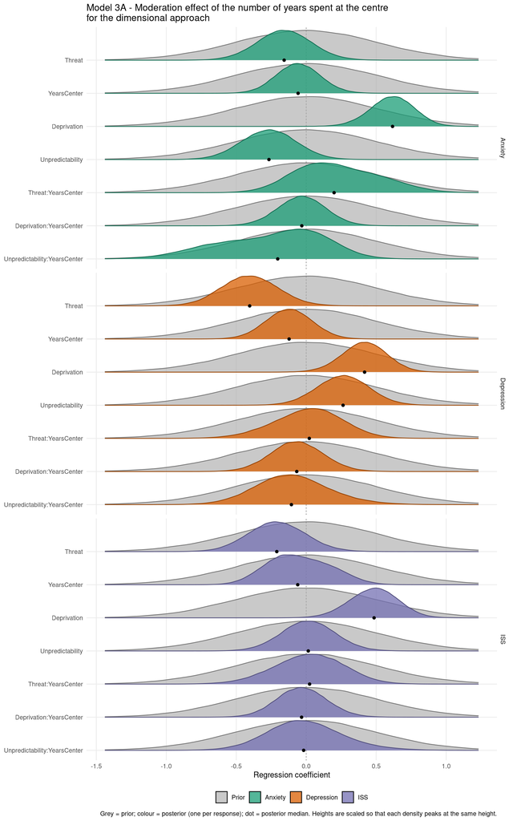

#### Prior and posterior predictive checks

##### Density overlays

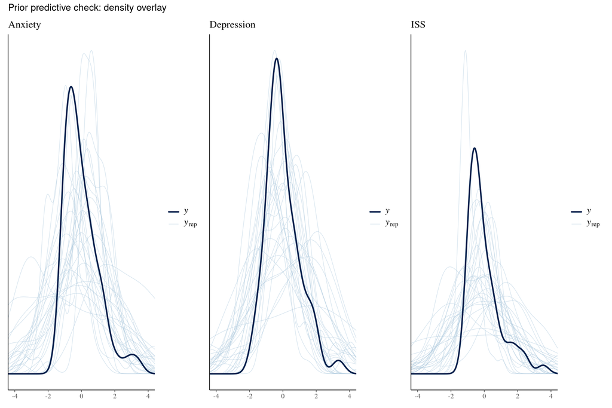

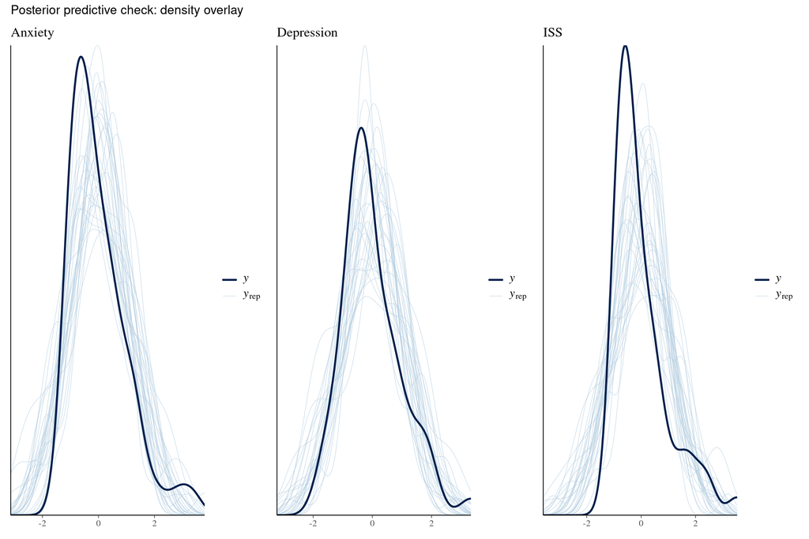

##### Minimum, Maximum and Skewness

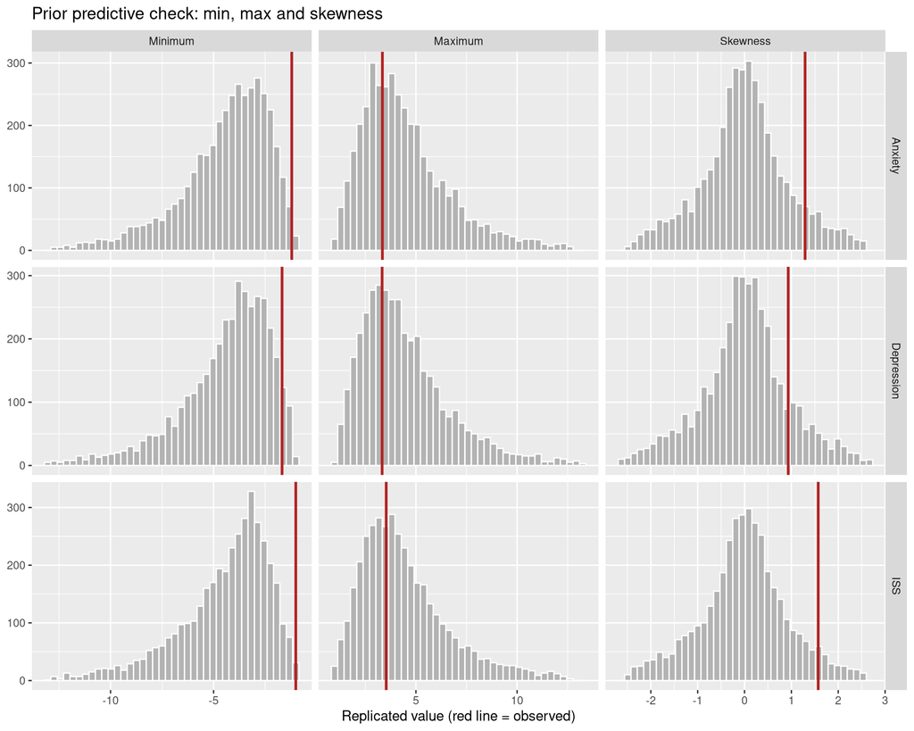

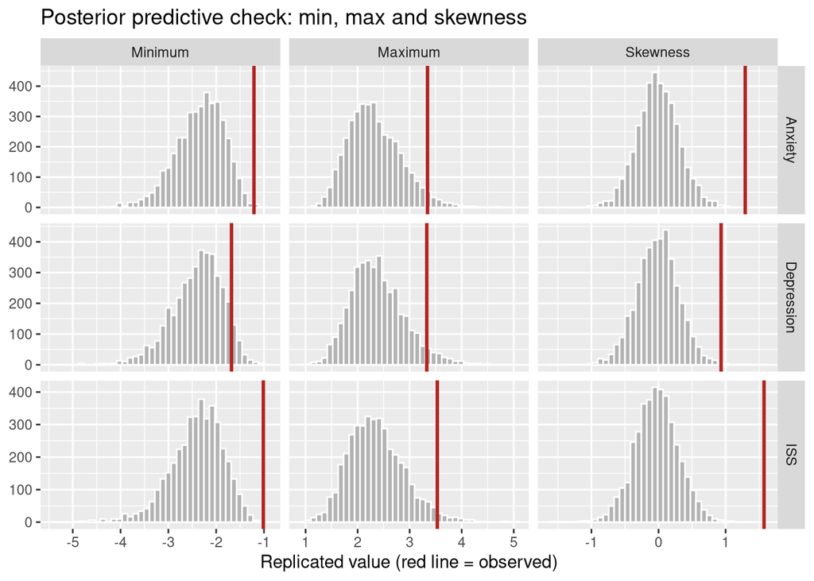

##### Pairwise correlation between dependent variables

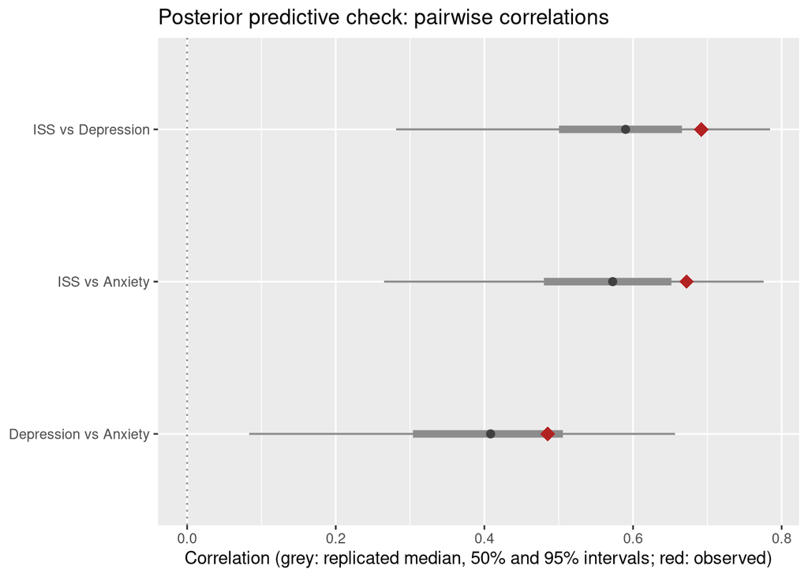

### Model 3B - Moderation effect of the number of years spent at the centre for the cumulative risk approach

| Parameter | Posterior Estimate | Posterior **95% CrI** | P(direction) | Convergence Rhat | Convergence Bulk ESS | Convergence Tail ESS |
| --- | --- | --- | --- | --- | --- | --- |
| Model 3B |  |  |  |  |  |  |
| Anxiety_Sex_2female | −0.22 | [−0.68, 0.24] | 0.836 | 1.001 | 4,431 | 4,503 |
| Anxiety_Sex_2male | 0.14 | [−0.28, 0.56] | 0.757 | 1.001 | 4,429 | 4,392 |
| Anxiety_CRS_2 | 0.17 | [−0.13, 0.45] | 0.871 | 1.002 | 4,750 | 5,137 |
| Anxiety_YearsCenter | 0.09 | [−0.20, 0.38] | 0.742 | 1.001 | 5,083 | 5,073 |
| Anxiety_CRS_2:YearsCenter | −0.02 | [−0.31, 0.26] | 0.566 | 1.001 | 4,713 | 4,923 |
| Depression_Sex_2female | 0.14 | [−0.29, 0.56] | 0.745 | 1.001 | 4,993 | 4,905 |
| Depression_Sex_2male | −0.17 | [−0.55, 0.23] | 0.809 | 1.001 | 4,921 | 4,193 |
| Depression_CRS_2 | 0.24 | [−0.04, 0.53] | 0.953 | 1.001 | 4,721 | 4,804 |
| Depression_YearsCenter | −0.02 | [−0.31, 0.26] | 0.568 | 1.002 | 4,684 | 4,971 |
| Depression_CRS_2:YearsCenter | −0.17 | [−0.46, 0.11] | 0.883 | 1.002 | 4,411 | 5,167 |
| ISS_Sex_2female | 0.02 | [−0.42, 0.47] | 0.535 | 1.001 | 4,664 | 4,425 |
| ISS_Sex_2male | −0.01 | [−0.40, 0.38] | 0.526 | 1.001 | 4,969 | 4,955 |
| ISS_CRS_2 | 0.24 | [−0.05, 0.52] | 0.951 | 1.001 | 4,168 | 5,162 |
| ISS_YearsCenter | 0.05 | [−0.29, 0.43] | 0.589 | 1.003 | 4,492 | 5,431 |
| ISS_CRS_2:YearsCenter | −0.04 | [−0.36, 0.33] | 0.577 | 1.002 | 4,347 | 5,084 |
| sd_Species_2__Anxiety_Intercept | 0.29 | [0.02, 0.95] |  | 1.002 | 2,149 | 2,341 |
| sd_Species_2__Depression_Intercept | 0.19 | [0.01, 0.75] |  | 1.002 | 2,584 | 2,883 |
| sd_Species_2__ISS_Intercept | 0.21 | [0.01, 0.77] |  | 1.003 | 2,231 | 2,767 |
| sigma_Anxiety | 0.96 | [0.79, 1.18] |  | 1.001 | 5,293 | 4,876 |
| sigma_Depression | 0.95 | [0.79, 1.17] |  | 1.001 | 5,664 | 5,239 |
| sigma_ISS | 0.95 | [0.79, 1.17] |  | 1.001 | 4,841 | 5,078 |
| rescor__Anxiety__Depression | 0.51 | [0.27, 0.68] | 1.000 | 1.001 | 5,029 | 5,405 |
| rescor__Anxiety__ISS | 0.63 | [0.42, 0.77] | 1.000 | 1.001 | 4,929 | 5,118 |
| rescor__Depression__ISS | 0.64 | [0.44, 0.78] | 1.000 | 1.002 | 6,129 | 5,687 |

Estimates are posterior medians or means pooled across imputed datasets; intervals are equal-tailed 95% CrIs.  
P(direction) = probability of direction.  
Convergence diagnostics are the worst values across imputations; shaded cells have Rhat > 1.01 or ESS < 400.

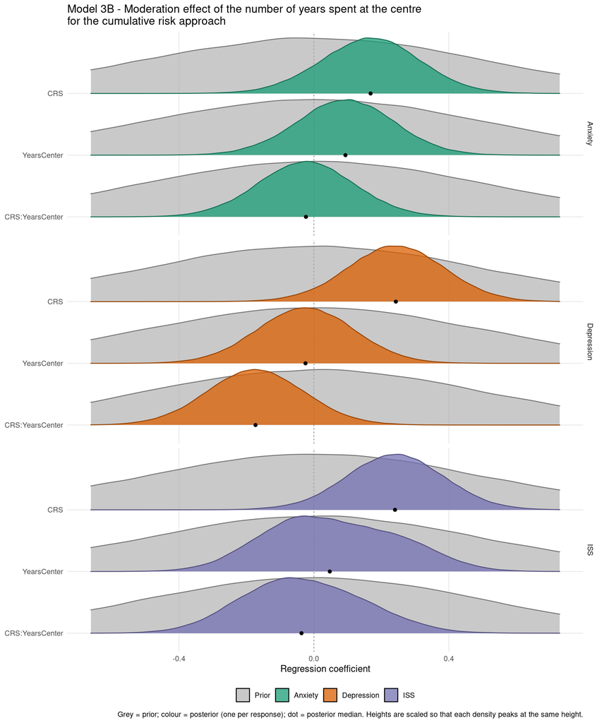

#### Prior and posterior predictive checks

##### Density overlays

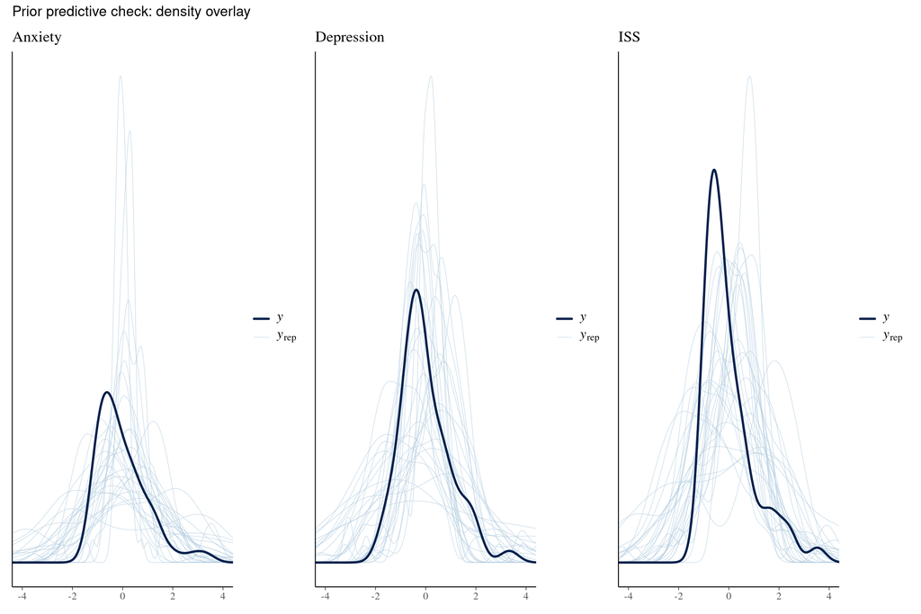

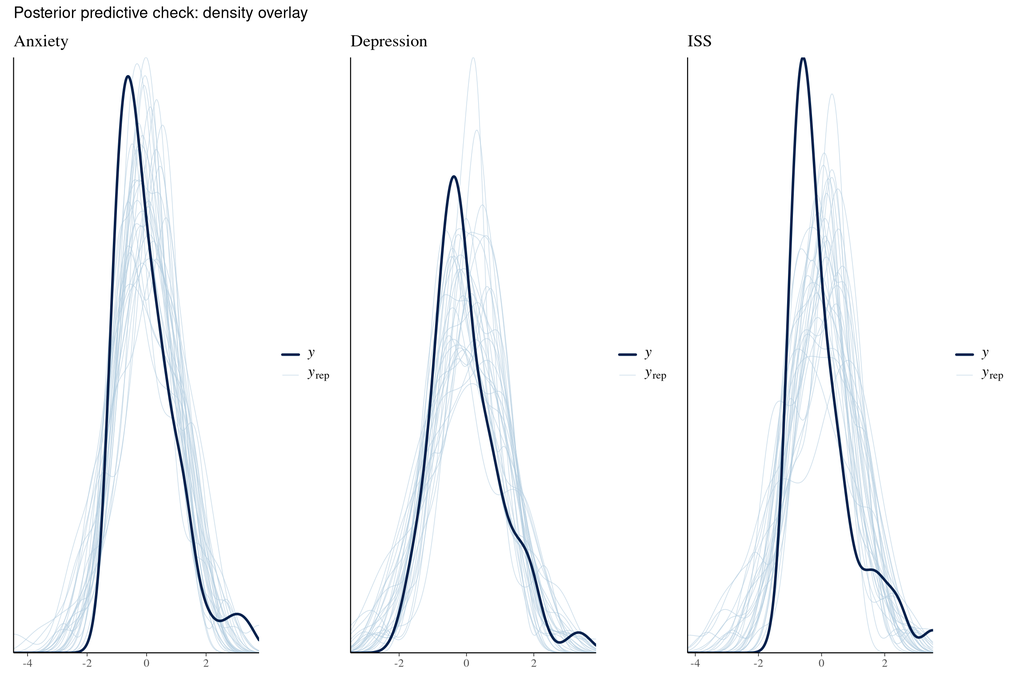

##### Minimum, Maximum and Skewness

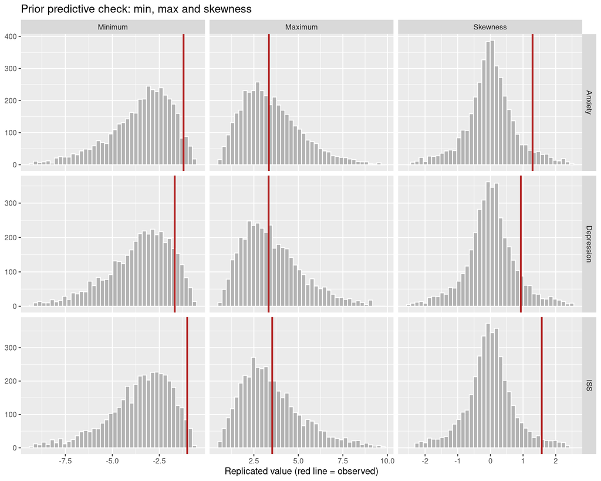

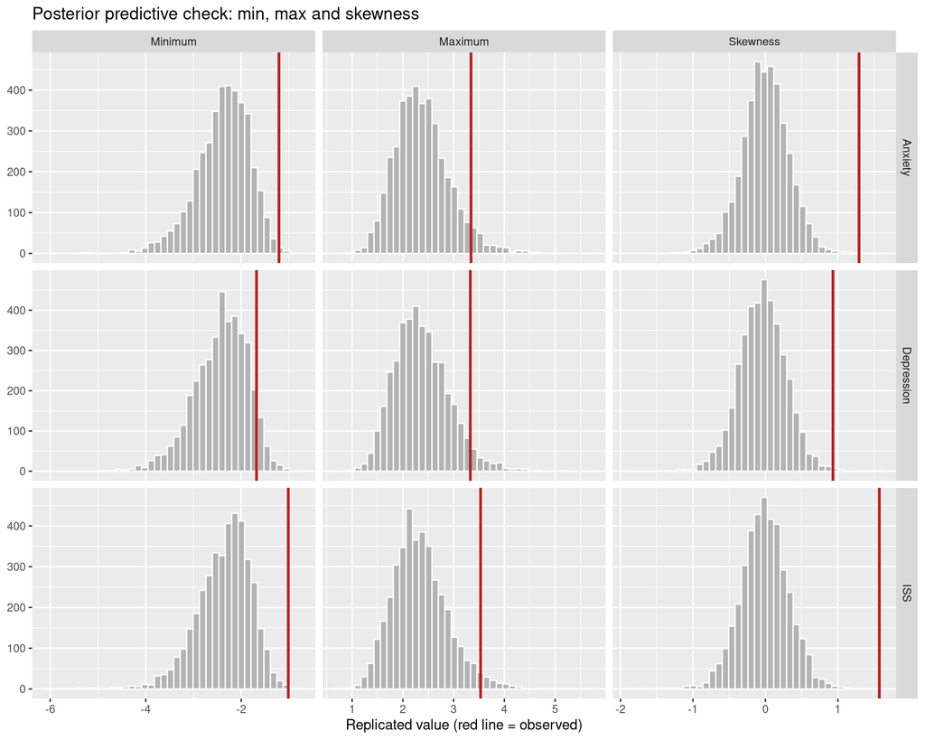

##### Pairwise correlation between dependent variables

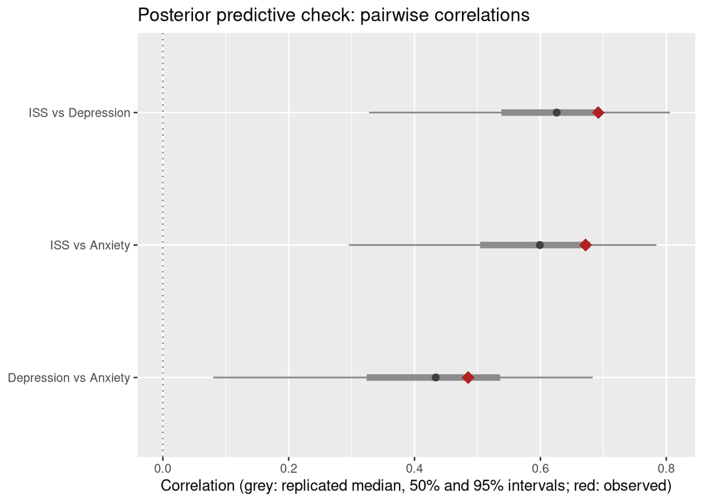

### Model comparisons

#### Dimensional approach vs cumulative approach

|  | elpd_diff | se_diff | elpd_loo | se_elpd_loo | p_loo | se_p_loo | looic | se_looic |
| --- | --- | --- | --- | --- | --- | --- | --- | --- |
| Dimensional model 1A | 0.00 | 0.00 | -195.98 | 16.71 | 27.82 | 7.06 | 391.96 | 33.41 |
| Cumulative model 1B | -7.22 | 4.22 | -203.20 | 17.96 | 23.33 | 6.96 | 406.41 | 35.92 |

|  | elpd_diff | se_diff | elpd_loo | se_elpd_loo | p_loo | se_p_loo | looic | se_looic |
| --- | --- | --- | --- | --- | --- | --- | --- | --- |
| Dimensional model 2A | 0.00 | 0.00 | -199.24 | 14.41 | 35.47 | 7.07 | 398.47 | 28.82 |
| Cumulative model 2B | -2.43 | 5.48 | -201.66 | 16.64 | 28.00 | 6.69 | 403.32 | 33.28 |

|  | elpd_diff | se_diff | elpd_loo | se_elpd_loo | p_loo | se_p_loo | looic | se_looic |
| --- | --- | --- | --- | --- | --- | --- | --- | --- |
| Dimensional model 3A | 0.00 | 0.00 | -205.11 | 16.07 | 37.45 | 7.44 | 410.23 | 32.15 |
| Cumulative model 3B | -3.35 | 3.76 | -208.47 | 17.34 | 28.47 | 6.83 | 416.94 | 34.68 |

#### Model without moderators vs model with moderators

**Estimated age at the center**

|  | elpd_diff | se_diff | elpd_loo | se_elpd_loo | p_loo | se_p_loo | looic | se_looic |
| --- | --- | --- | --- | --- | --- | --- | --- | --- |
| Dimensional model without moderators | 0.00 | 0.00 | -195.95 | 16.69 | 27.78 | 7.04 | 391.89 | 33.38 |
| Dimensional model with EstimatedAgeArrival as moderator | -3.35 | 4.87 | -199.30 | 14.46 | 35.53 | 7.10 | 398.60 | 28.91 |

**Years spent at the center**

|  | elpd_diff | se_diff | elpd_loo | se_elpd_loo | p_loo | se_p_loo | looic | se_looic |
| --- | --- | --- | --- | --- | --- | --- | --- | --- |
| Dimensional model without moderators | 0.00 | 0.00 | -195.94 | 16.69 | 27.78 | 7.04 | 391.88 | 33.37 |
| Dimensional model with YearsCenter as moderator | -9.18 | 2.86 | -205.12 | 16.08 | 37.45 | 7.44 | 410.24 | 32.16 |

## Supplementary

### Summary table with predictors for all models explored

| Parameter | Posterior Estimate | Posterior **95% CrI** | P(direction) | Convergence Rhat | Convergence Bulk ESS | Convergence Tail ESS |
| --- | --- | --- | --- | --- | --- | --- |
| model_multi_1A |  |  |  |  |  |  |
| Anxiety_Threat | −0.17 | [−0.50, 0.18] | 0.835 | 1.001 | 4,658 | 5,044 |
| Anxiety_Deprivation | 0.58 | [0.29, 0.86] | 1.000 | 1.001 | 5,046 | 5,064 |
| Anxiety_Unpredictability | −0.21 | [−0.54, 0.13] | 0.886 | 1.001 | 4,827 | 5,153 |
| Depression_Threat | −0.39 | [−0.74, −0.03] | 0.982 | 1.002 | 4,576 | 5,122 |
| Depression_Deprivation | 0.36 | [0.05, 0.66] | 0.989 | 1.001 | 5,275 | 5,215 |
| Depression_Unpredictability | 0.28 | [−0.07, 0.63] | 0.941 | 1.002 | 4,632 | 5,189 |
| ISS_Threat | −0.18 | [−0.53, 0.18] | 0.838 | 1.001 | 4,173 | 4,684 |
| ISS_Deprivation | 0.47 | [0.16, 0.77] | 0.998 | 1.001 | 4,608 | 5,176 |
| ISS_Unpredictability | 0.00 | [−0.35, 0.36] | 0.508 | 1.001 | 4,512 | 4,672 |
| model_multi_1B |  |  |  |  |  |  |
| Anxiety_CRS | 0.26 | [0.00, 0.52] | 0.976 | 1.002 | 4,602 | 5,224 |
| Depression_CRS | 0.24 | [−0.01, 0.50] | 0.969 | 1.001 | 5,492 | 5,170 |
| ISS_CRS | 0.30 | [0.04, 0.55] | 0.989 | 1.001 | 4,597 | 4,891 |
| model_multi_1C |  |  |  |  |  |  |
| Anxiety_CRS_2 | 0.14 | [−0.13, 0.40] | 0.849 | 1.001 | 4,254 | 5,155 |
| Depression_CRS_2 | 0.18 | [−0.08, 0.44] | 0.916 | 1.001 | 4,750 | 5,495 |
| ISS_CRS_2 | 0.21 | [−0.05, 0.47] | 0.947 | 1.001 | 3,958 | 5,278 |
| model_multi_1D |  |  |  |  |  |  |
| Anxiety_Harshness | 0.42 | [0.08, 0.75] | 0.992 | 1.002 | 4,225 | 4,688 |
| Anxiety_Unpredictability | −0.30 | [−0.65, 0.04] | 0.960 | 1.001 | 4,188 | 5,157 |
| Depression_Harshness | 0.03 | [−0.32, 0.38] | 0.566 | 1.001 | 4,080 | 4,895 |
| Depression_Unpredictability | 0.18 | [−0.17, 0.53] | 0.843 | 1.001 | 4,249 | 4,940 |
| ISS_Harshness | 0.29 | [−0.05, 0.63] | 0.952 | 1.001 | 4,089 | 5,084 |
| ISS_Unpredictability | −0.08 | [−0.42, 0.28] | 0.664 | 1.002 | 3,907 | 4,864 |
| model_multi_2A |  |  |  |  |  |  |
| Anxiety_Threat | −0.19 | [−0.59, 0.21] | 0.825 | 1.001 | 5,437 | 5,441 |
| Anxiety_EstimatedAgeArrival | 0.03 | [−0.37, 0.44] | 0.558 | 1.002 | 5,019 | 5,290 |
| Anxiety_Deprivation | 0.53 | [0.10, 0.96] | 0.992 | 1.002 | 4,528 | 5,110 |
| Anxiety_Unpredictability | −0.30 | [−0.64, 0.04] | 0.960 | 1.001 | 5,881 | 5,333 |

[output cut: 307 more lines]

Estimates are posterior medians or means pooled across imputed datasets; intervals are equal-tailed 95% CrIs.  
P(direction) = probability of direction.  
Convergence diagnostics are the worst values across imputations; shaded cells have Rhat > 1.01 or ESS < 400.